# MAE augmentation - Calculated variables at the participant and study day level

```r
# output in Excel for Caroline

t1 <- dictionnary |>
  distinct(medication, is_abx) |>
  arrange(-is_abx, medication)
t2 <- dictionnary |> distinct(route, route_description) |> arrange(route)
t3 <- dictionnary |>
  filter(is_abx) |>
  distinct(medication, abx_compound) |>
  arrange(abx_compound, medication)
t4 <- dictionnary |>
  filter(is_abx) |>
  distinct(abx_compound, route_description, abx_cat) |>
  arrange(abx_compound, route_description) |>
  mutate(
    comments = case_when(
      abx_compound == "Metronidazole" &
        route_description ==
          "Intramuscular" ~ "Is it ok to categorize intramuscular metronidazole as oral metronidazole (cm_oral_mtz) ?",
      abx_compound == "Metronidazole" &
        route_description ==
          "Blank" ~ "Is it ok to categorize metronidazole with missing route as oral metronidazole (cm_oral_mtz) ?",
      TRUE ~ ""
    )
  )

openxlsx::write.xlsx(
  list(
    medication_is_abx = t1,
    route_description = t2,
    abx_medication_compound = t3,
    abx_compound_route_cat = t4
  ),
  file = "dictionary_check_caroline.xlsx"
)
```

We only are interest in supplementary antibiotics taken during the study period.

```r
suppl_antibiotics_crf31 <-
  crf31 |>
  select(
    pid,
    site,
    pid_label,
    med_start_relative_date,
    med_stop_relative_date,
    medication,
    route
  ) |>
  left_join(
    dictionnary |>
      select(medication, route, is_abx, abx_cat, abx_compound) |>
      distinct(),
    by = c("medication", "route")
  ) |>
  filter(is_abx) |>
  mutate(
    med_stop_relative_date_modified = ifelse(
      is.na(med_stop_relative_date),
      med_start_relative_date,
      med_stop_relative_date
    )
  )
```

*Note : stars represent participants not included in the PP population*

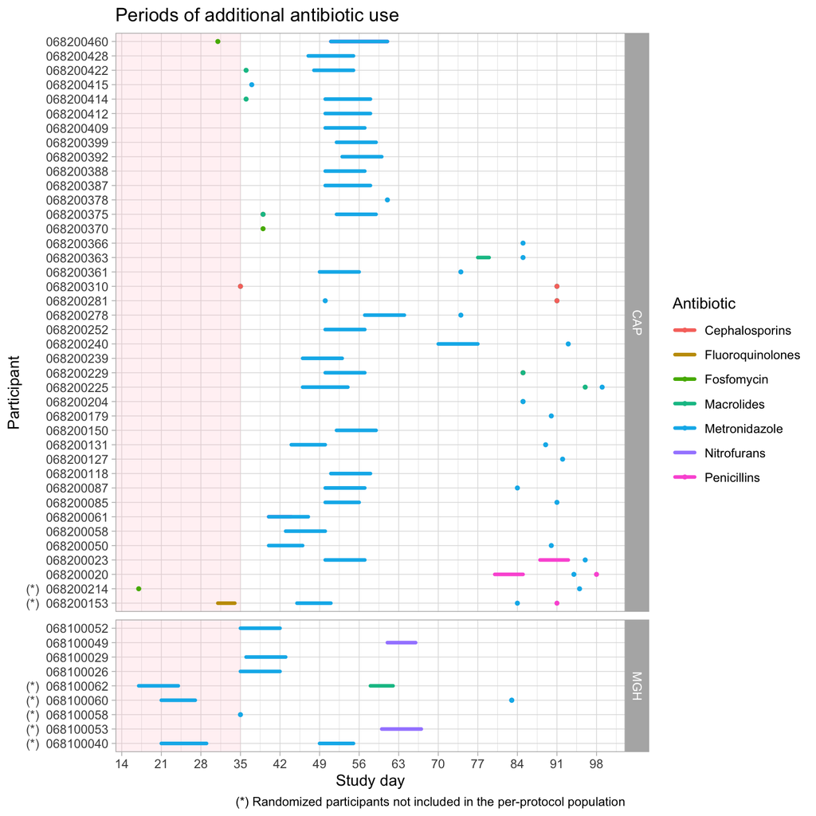

```r
# by antibiotic compound

suppl_antibiotics_crf31 |>
  ggplot() +
  aes(
    x = med_start_relative_date,
    xend = med_stop_relative_date_modified,
    y = pid_label,
    color = abx_compound
  ) +
  annotate(
    "rect",
    xmin = -Inf,
    xmax = 35,
    ymin = -Inf,
    ymax = Inf,
    fill = "pink",
    alpha = 0.2
  ) +
  geom_segment(linewidth = 1.2, lineend = "round") +
  geom_point(
    data = suppl_antibiotics_crf31 |>
      filter(
        med_start_relative_date == med_stop_relative_date_modified,
        is_abx
      ),
    aes(x = med_start_relative_date),
    size = 1
  ) +
  facet_grid(site ~ ., scales = "free_y", space = "free_y") +
  labs(
    x = "Study day",
    y = "Participant",
    color = "Antibiotic",
    title = "Periods of additional antibiotic use",
    caption = "(*) Randomized participants not included in the per-protocol population"
  ) +
  scale_x_continuous(breaks = seq(0, 100, by = 7))
```

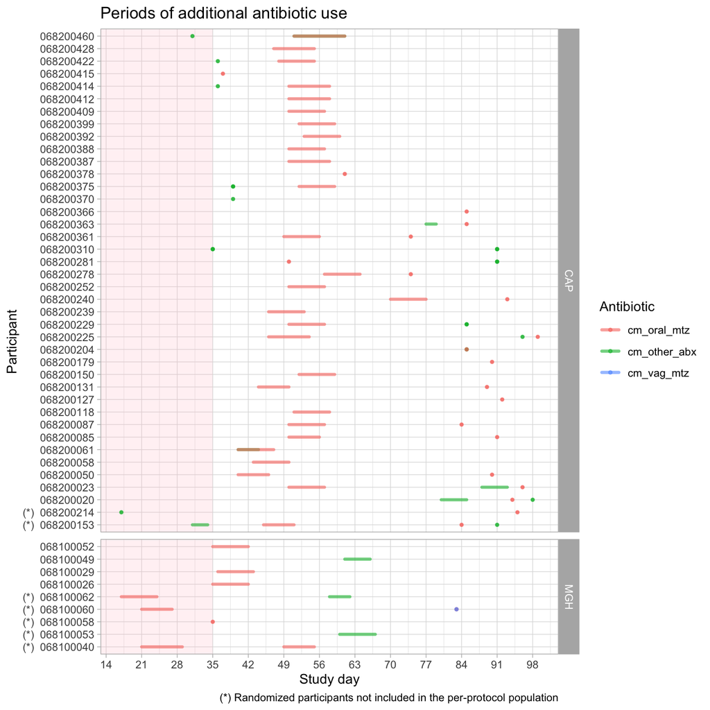

```r
# by antibiotics cat

suppl_antibiotics_crf31 |>
  filter(is_abx) |>
  ggplot() +
  aes(
    x = med_start_relative_date,
    xend = med_stop_relative_date_modified,
    y = pid_label,
    color = abx_cat
  ) +
  annotate(
    "rect",
    xmin = -Inf,
    xmax = 35,
    ymin = -Inf,
    ymax = Inf,
    fill = "pink",
    alpha = 0.2
  ) +
  geom_segment(linewidth = 1.2, lineend = "round", alpha = 0.6) +
  geom_point(
    data = suppl_antibiotics_crf31 |>
      filter(
        med_start_relative_date == med_stop_relative_date_modified,
        is_abx
      ),
    aes(x = med_start_relative_date),
    alpha = 0.6,
    size = 1
  ) +
  facet_grid(site ~ ., scales = "free_y", space = "free_y") +
  labs(
    x = "Study day",
    y = "Participant",
    color = "Antibiotic",
    title = "Periods of additional antibiotic use",
    caption = "(*) Randomized participants not included in the per-protocol population"
  ) +
  scale_x_continuous(breaks = seq(0, 100, by = 7))
```

### CRF 20 - Antibiotics

In the CRF20 it was ask wheter the participants took antibiotics (vaginal or oral) or any probiotics (vaginal or oral) or something for yeast, lubricant, etc. during the past week. This CRF was fill every clinical visit (from V1 to V9).

For this data, we know if a participants took antibiotics during the past week but we don’t know the exact day of antibiotic use.

One participant (068200457) have a empty value (““, and not `NA`). We will consider this value as missing.

```r
crf20 <-
  metadata(mae)$visits_crfs_merged |>
  left_join(
    colData(mae) |>
      as_tibble() |>
      select(pid, ITT, mITT, PP, randomized, site) |>
      distinct()
  ) |>
  filter(randomized) |>
  select(pid, visit_code, study_day, PP, site, used_during_past_week)

crf20 |>
  dplyr::count(used_during_past_week) |>
  gt::gt(caption = "Antibiotics/probiotics use during the past week, by visit")
```

Antibiotics/probiotics use during the past week, by visit

| used_during_past_week | n |
| --- | --- |
| none | 755 |
| lube_with_sex | 33 |
| oral_antibiotic | 4 |
| vaginal_yeast | 4 |
| lube_masturbation | 3 |
| oral_probiotic | 3 |
| oral_yeast | 2 |
|  | 1 |
| lube_masturbation, lube_with_sex | 1 |
| lube_with_sex, oral_probiotic | 1 |
| lube_with_sex, oral_yeast | 1 |
| lube_with_sex, vaginal_antibiotic | 1 |
| oral_antibiotic, oral_yeast | 1 |
| vaginal_antibiotic | 1 |
| vaginal_probiotic | 1 |
| NA | 3226 |

We only look at the vaginal/oral antibiotics.

```r
suppl_antibiotics_crf20 <-
  crf20 |>
  filter(str_detect(used_during_past_week, "antibiotic")) |>
  mutate(
    used_during_past_week = str_remove(
      used_during_past_week,
      "lube_with_sex"
    ) |>
      str_remove("oral_yeast") |>
      str_replace_all(",\\s*", ""),
    pid_label = ifelse(!PP, paste("(*) ", pid), pid),
    window_start = study_day - 7,
    window_end = study_day
  )

suppl_antibiotics_crf20 |>
  dplyr::count(used_during_past_week) |>
  gt::gt(caption = "Antibiotics/probiotics use during the past week, by visit")
```

Antibiotics/probiotics use during the past week, by visit

| used_during_past_week | n |
| --- | --- |
| oral_antibiotic | 5 |
| vaginal_antibiotic | 2 |

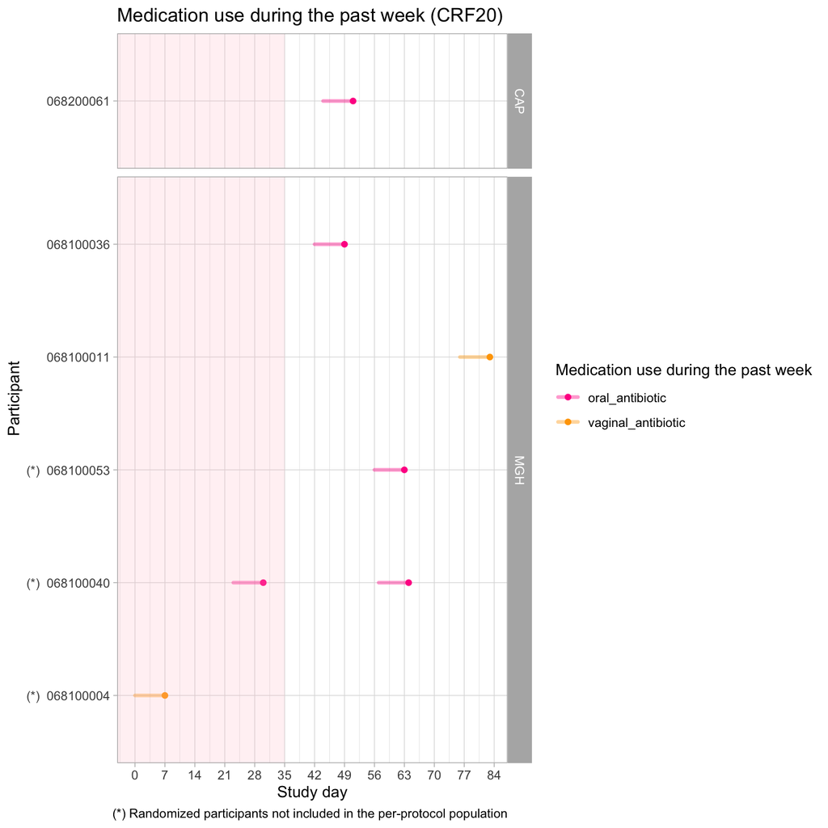

```r
suppl_antibiotics_crf20 |>
  ggplot() +
  aes(
    x = study_day,
    y = pid_label,
    color = used_during_past_week
  ) +
  geom_point() +
  geom_segment(
    aes(x = window_start, xend = window_end, y = pid_label, yend = pid_label),
    linewidth = 1.2,
    lineend = "round",
    alpha = 0.4
  ) +
  annotate(
    "rect",
    xmin = -Inf,
    xmax = 35,
    ymin = -Inf,
    ymax = Inf,
    fill = "pink",
    alpha = 0.2
  ) +
  facet_grid(site ~ ., scales = "free_y", space = "free_y") +
  scale_color_manual(
    "Medication use during the past week",
    values = c(
      "oral_antibiotic" = "deeppink",
      "vaginal_antibiotic" = "orange"
    )
  ) +
  scale_y_discrete(drop = FALSE) +
  labs(
    x = "Study day",
    y = "Participant",
    color = "Medication use during the past week",
    title = "Medication use during the past week (CRF20)",
    caption = "(*) Randomized participants not included in the per-protocol population"
  ) +
  scale_x_continuous(breaks = seq(0, 100, by = 7))
```

We combine the information from this CRF with the information from CRF31. The goal is to check if the antibiotics reported in CRF31 overlap with the periods of antibiotic use reported in CRF20, and to identify any discrepancies between the two sources of information. We also want to see if there are any antibiotics reported in CRF20 that are not captured in CRF31.

```r
suppl_antibiotics_crf31_long <-
  suppl_antibiotics_crf31 |>
  filter(is_abx) |>
  select(
    pid,
    pid_label,
    site,
    med_start_relative_date,
    med_stop_relative_date_modified,
    is_abx,
    abx_cat,
    abx_compound
  ) |>
  rowwise() |>
  mutate(
    study_day = list(med_start_relative_date:med_stop_relative_date_modified)
  ) |>
  unnest(study_day) |>
  select(-med_start_relative_date, -med_stop_relative_date_modified) |>
  ungroup()

# suppl_antibiotics_crf31_long <-
#   suppl_antibiotics_crf31_long |>
#   group_by(pid, pid_label, site, study_day) |>
#   summarise(
#     abx_cat = paste(abx_cat, collapse = "; "),
#     abx_compound = paste(abx_compound, collapse = "; "),
#     .groups = "drop"
#   )

suppl_antibiotics_crf20_long <-
  suppl_antibiotics_crf20 |>
  select(
    pid,
    pid_label,
    site,
    crf20_start = window_start,
    crf20_end = window_end,
    antibiotics_crf20 = used_during_past_week
  ) |>
  rowwise() |>
  mutate(study_day = list(crf20_start:crf20_end)) |>
  unnest(study_day) |>
  ungroup() |>
  select(pid, pid_label, site, study_day, antibiotics_crf20)
```

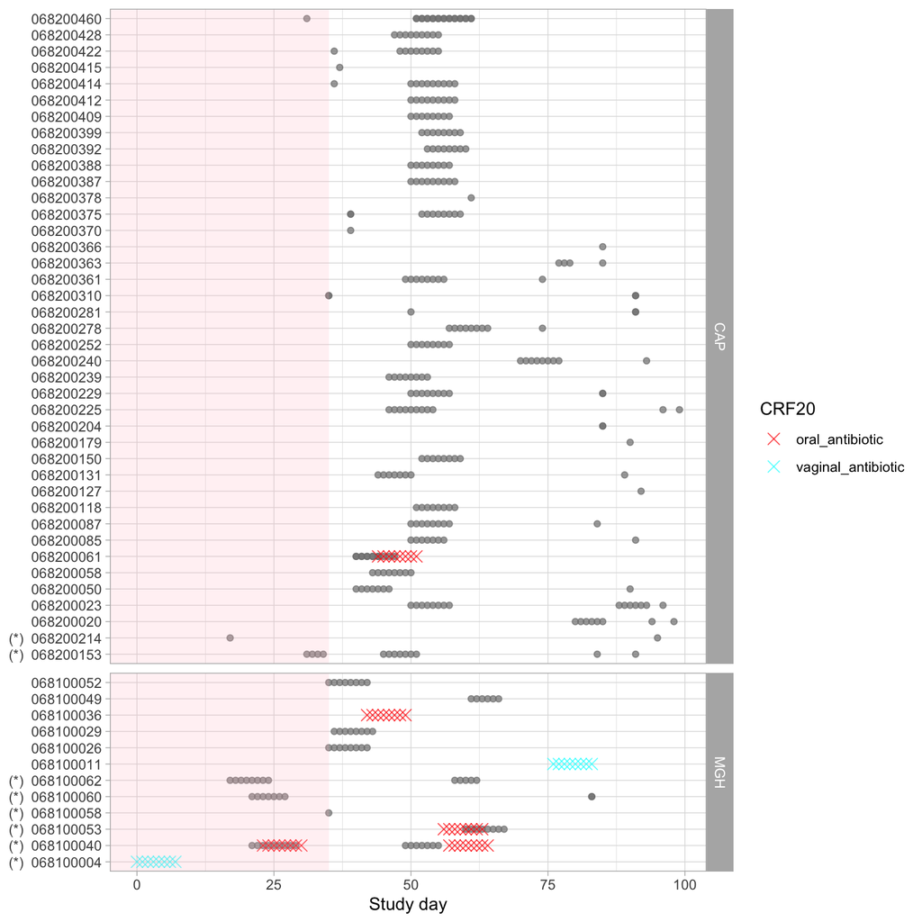

```r
library(ggnewscale)

ggplot() +
  # CRF31
  geom_point(
    data = suppl_antibiotics_crf31_long,
    aes(x = study_day, y = pid_label, col = abx_cat),
    alpha = 0.7
  ) +
  scale_color_manual(
    name = "CRF31",
    values = c(
      "oral_mtz" = "pink",
      "oral_other_abx" = "purple",
      "vaginal_mtz" = "blue",
      "other_route_mtz" = "darkgreen",
      "other_route_other_abx" = "green"
    )
  ) +

  new_scale_color() +

  # CRF20
  geom_point(
    data = suppl_antibiotics_crf20_long,
    aes(x = study_day, y = pid_label, col = antibiotics_crf20),
    shape = 4,
    size = 3,
    alpha = 0.7
  ) +
  scale_color_manual(
    name = "CRF20",
    values = c(
      "oral_antibiotic" = "red",
      "vaginal_antibiotic" = "cyan"
    )
  ) +

  annotate(
    "rect",
    xmin = -Inf,
    xmax = 35,
    ymin = -Inf,
    ymax = Inf,
    fill = "pink",
    alpha = 0.2
  ) +
  facet_grid(site ~ ., scales = "free_y", space = "free_y") +
  labs(x = "Study day", y = NULL)
```

### Combining CRF20 and CRF31 information

We combine the information of both CRFs at the study_day level.

> TODO : harmonized the antibiotic categories between the two CRFs (e.g., oral_antibiotic in CRF20 could be oral_mtz or oral_other_abx in CRF31, etc.). TODO : check if the antibiotics reported in CRF31 overlap with the periods of antibiotic use reported in CRF20, and choose a strategy to handle any discrepancies between the two sources of information.

```r
suppl_antibiotics_crf20_long <-
  suppl_antibiotics_crf20_long |>
  mutate(
    abx_cat = case_when(
      antibiotics_crf20 == "oral_antibiotic" ~ "oral_other_abx",
      antibiotics_crf20 == "vaginal_antibiotic" ~ "vaginal_other_abx",
      TRUE ~ "???"
    )
  )
```

### Adding the supplementary antibiotic variable to the metadata

We only add the values of CRF31 in the metadata for now.

We add the summary variables for supplementary antibiotics to the `calc_vars_study_day` table in the metadata of the `mae` object. We create three dummy variable based on the `abx_cat` variable : `daily_exposure_cm_oral_mtz`, `daily_exposure_cm_vag_mtz`, and `daily_exposure_cm_other_abx`.

```r
# for now we only add the information from crf31
abx_dummies <-
  suppl_antibiotics_crf31_long |>
  select(pid, study_day, abx_cat) |>
  mutate(value = 1) |>
  pivot_wider(
    names_from = abx_cat,
    values_from = value,
    values_fill = 0,
    values_fn = max,
    names_prefix = "daily_exposure_"
  )

tmp <- mae@metadata$calc_vars_study_day

mae@metadata$calc_vars_study_day <-
  mae@metadata$calc_vars_study_day |>
  full_join(abx_dummies, by = c("pid", "study_day")) |>
  mutate(across(starts_with("daily_exposure_"), \(x) replace_na(x, 0)))
```

## Checking duplicates

We check if there are some duplicate combination of `pid` and `study_day` in the `calc_vars_study_day` table after adding the new variables. We don’t expect to have duplicates at this stage as we already removed duplicates for the vaginal insertion variable and we don’t expect any duplicates for the supplementary antibiotic variable.

```r
mae@metadata$calc_vars_study_day |>
  dplyr::count(pid, study_day) |>
  filter(n > 1)
```

```
# A tibble: 0 × 3
# ℹ 3 variables: pid <chr>, study_day <dbl>, n <int>
```

# Saving the `MultiAssayExperiment` objects

We save the MAE for downstream analyses.

```r
saveRDS(
  mae,
  str_c(
    get_03_output_dir(),
    "mae_full_03_",
    today() |> str_remove_all("-"),
    ".rds"
  )
)
```